# Relatório Final do inquérito OBSERVA II

2023-03-22

### Nota introdutória

O presente relatório foi elaborado no âmbito da unidade curricular de Análise Exploratória de Dados e visa analisar e interpretar os resultados obtidos do inquérito “OBSERVA II”, desenvolvido para determinar atitudes, comportamentos, cultura ambiental, opiniões e expectativas dos diferentes estratos populacionais relativamente ao estado do ambiente, à conservação da natureza, ao ordenamento do território e a outros temas associados ao ambiente. Neste documento pode ver-se a análise a um excerto das respostas obtidas na grande Lisboa.

### Análise geral do perfil sociodemográfico dos inquiridos

Para dar início à análise, começou-se por analisar o perfil sociodemográfico dos inquiridos, de forma a perceber se determinadores padrões de resposta no inquérito podem (ou não) ser associados a tais perfis. Esta análise visa aprofundar o conhecimento da amostra através da compreensão das suas características.

|  | N | % |
| --- | --- | --- |
| Feminino | 249 | 60.3 |
| Masculino | 164 | 39.7 |

###### Tabela 1 - Tabela de frequências por sexo

A amostra é constituida por um total de 413 respostas. Conforme se pode ver na tabela acima, no que diz respeito ao sexo, há uma maior predominância das respostas femininas, que perfazem 60.3% do total de inquiridos.

|  | N | % |
| --- | --- | --- |
| Lisboa | 310 | 75.1 |
| Setúbal | 103 | 24.9 |

###### Tabela 2 - Tabela de frequências por distrito de residência

Já no que diz respeito à análise do distrito de residência, 75.1% dos inquiridos são de Lisboa. Contudo, é importante ter em consideração que o objeto de análise contém apenas um excerto das respostas, correspondente à região da grande Lisboa.

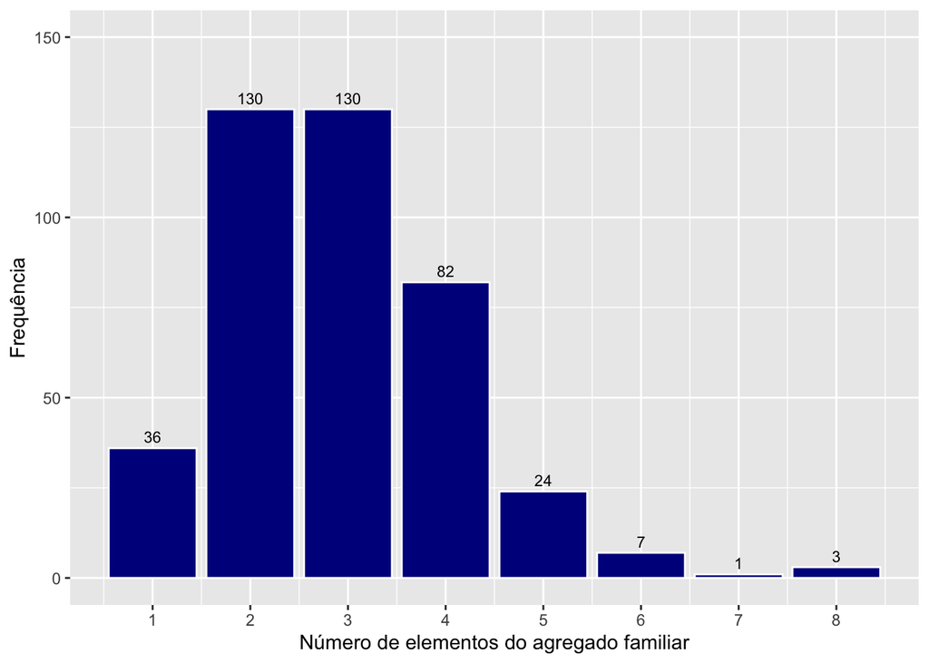

###### Figura 1 - Gráfico de barras do número de elementos do agregado familiar

Conforme se pode ver pela análise da figura acima, 260 inquiridos vivem com 2 ou 3 pessoas. Esta informação apresenta-se em conformidade com os dados dos últimos censos, que revelaram que a dimensão média dos agregados domésticos privados em Lisboa ronda as 2/3 pessoas [1]. Já a nível nacional, os agregados com duas pessoas continuam os mais prevalentes (33,3%) [1].

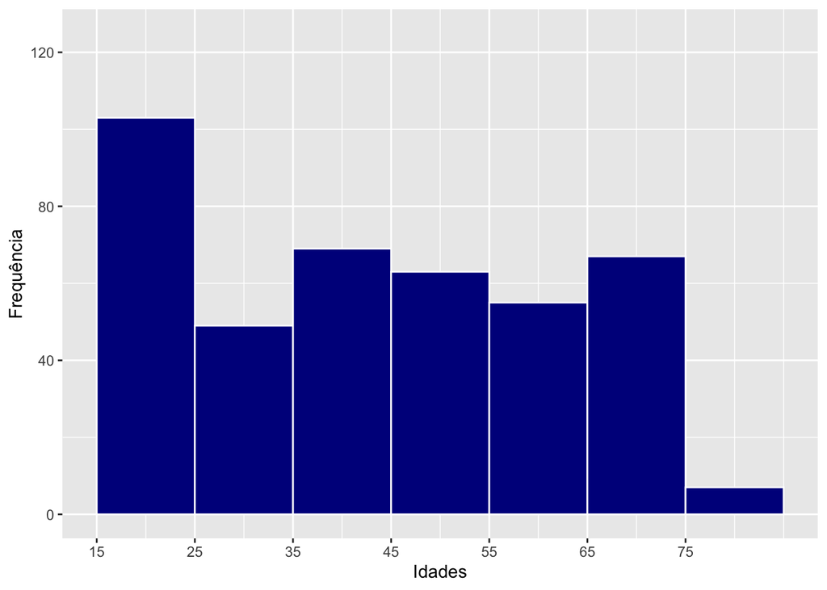

###### Figura 2 - Histograma com a distribuição das idades

O histograma acima mostra a distribuição das idades dos inquiridos e a sua assimetria é justificada pelo maior número de respostas dadas pelos jovens com idades compreendidas entre os 15 e os 24 anos.

| Medidas | Valor |
| --- | --- |
| N | 413.0 |
| Média | 44.0 |
| Mediana | 43.0 |
| Desvio padrão | 18.6 |
| Variância | 347.2 |
| Mínimo | 15.0 |
| Máximo | 85.0 |
| Quartil 1 | 26.0 |
| Quartil 3 | 59.0 |
| Assimetria | 0.1 |
| Curtose | 1.7 |

###### Tabela 3 - Tabela de medidas descritivas para a variável Idade

Ao aprofundar a análise com a tabela de medidas descritivas para a idade dos inquiridos, conseguimos perceber que o estudo contém respostas de inquiridos com idades compreendidas entre os 15 e os 85 anos.

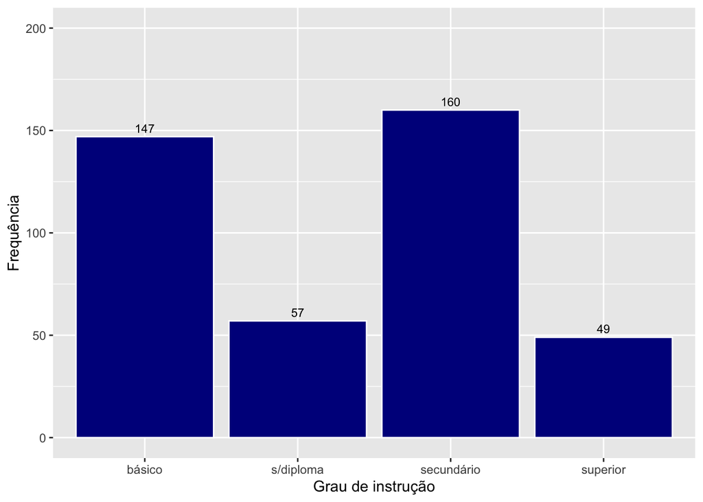

###### Figura 3 - Gráfico de barras com o grau de instrução do inquirido

Ao nível das habilitações, é importante ter em consideração que um elevado volume de respostas (88.1%) é dado por pessoas que não seguiram para o ensino superior. Entre os graus mais representados nesta amostra, destaca-se o ensino secundário com 160 respostas, seguindo-se do ensino básico com 147 respostas.

### Análise das respostas ao questionário

#### Preferência para viver

|  | N | % |
| --- | --- | --- |
| Litoral | 293 | 70.9 |
| Interior | 98 | 23.7 |
| Não respondeu | 22 | 5.3 |

###### Tabela 4 - Tabela de frequências para a variável “Preferência para viver”

No que diz respeito às respostas ao questionário, a maior preferência é dada pelo litoral de Portugal (70.9%). Apenas 22 dos 413 inquiridos optaram por não responder a esta questão.

|  | Interior | Litoral | Não respondeu | % Interior | % Litoral | % Não respondeu |
| --- | --- | --- | --- | --- | --- | --- |
| Feminino | 55 | 179 | 15 | 13.3 | 43.3 | 3.6 |
| Masculino | 43 | 114 | 7 | 10.4 | 27.6 | 1.7 |

###### Tabela 5 - Tabela de contigência “Sexo” x “Preferência para viver”

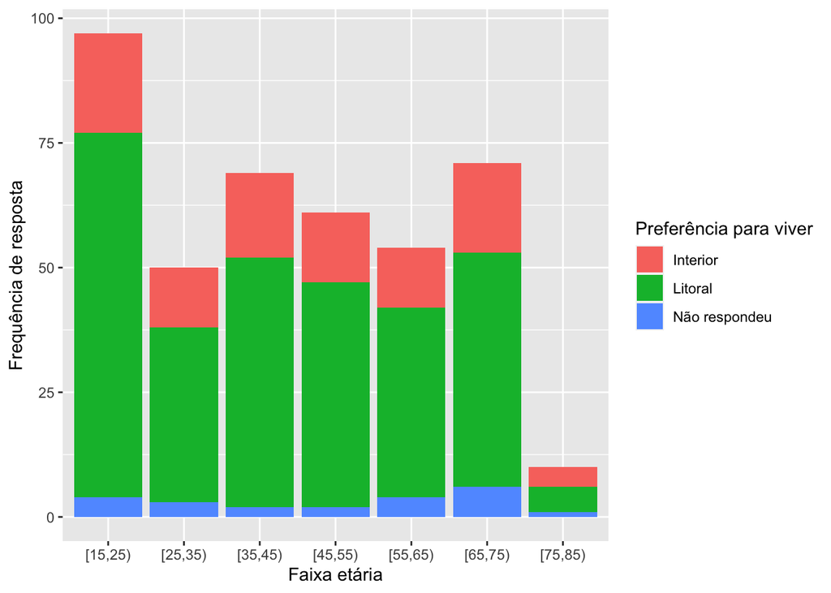

###### Figura 4 - Gráfico de barras empilhadas “Faixa etária” x “Preferência para viver”

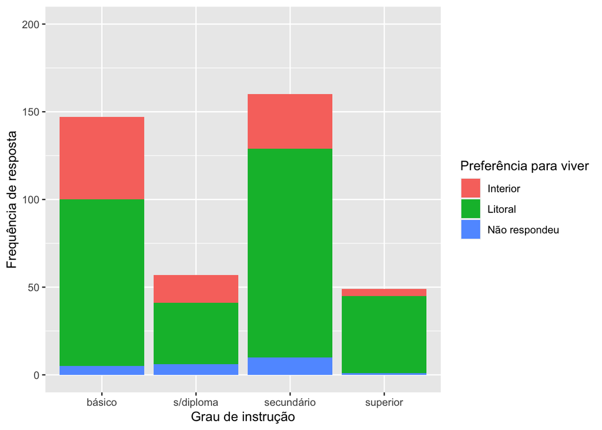

###### Figura 5 - Gráfico de barras empilhadas “Grau de instrução” x “Preferência para viver”

Na imagem acima torna-se mais evidente que a maior preferência pelo interior é tido por pessoas com o ensino básico, ao passo que a esmagadora maioria dos inquiridos com o ensino superior mostrou ter uma preferência clara pelo litoral para viver.

#### Impacto da produção industrial no ambiente

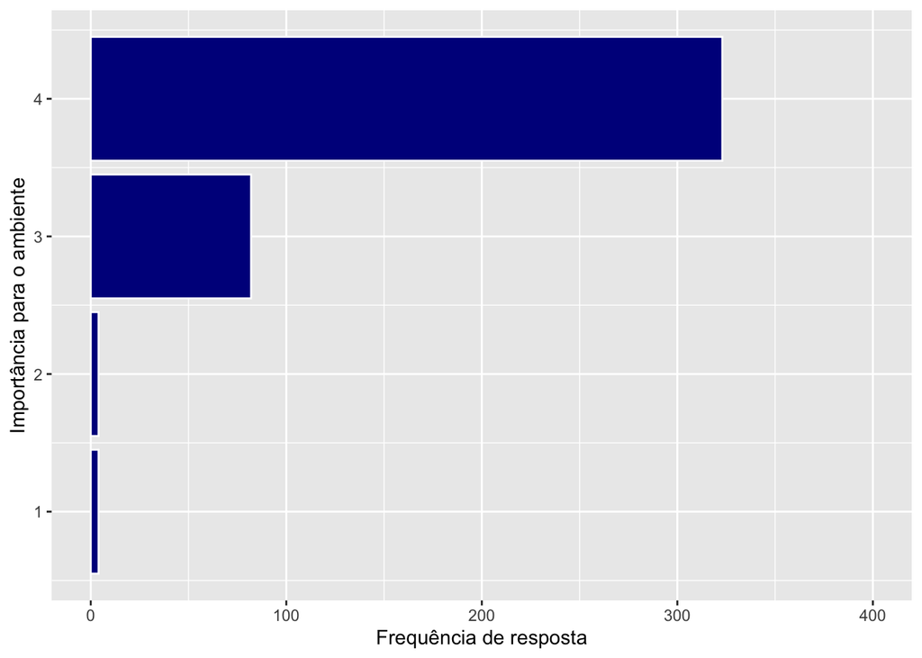

###### Figura 6 - Gráfico de barras horizontais do impacto da produção industrial no ambiente

A figura acima ilustra as classificações atribuídas pelos inquiridos, numa escala onde 1 representa nada importante e 4 muito importante, no que diz respeito ao impacto que a produção industrial tem no ambiente. Tal como se pode constatar na imagem, a produção industrial revela-se entre as principais preocupações dos habitantes da grande Lisboa no que toca às questões ambientais.

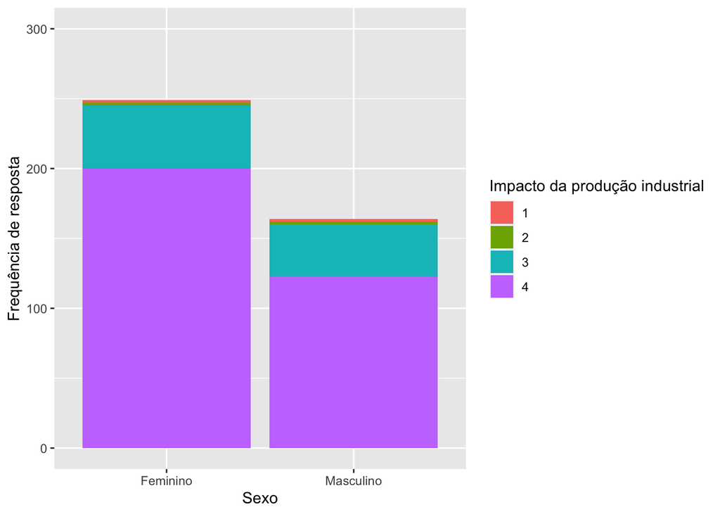

###### Figura 7 - Gráfico de barras empilhadas “Sexo” x “Impacto da produção industrial no ambiente”

De uma forma geral, a importância atribuída ao impacto da indústria no ambiente é alta e semelhante entre mulheres e homens.

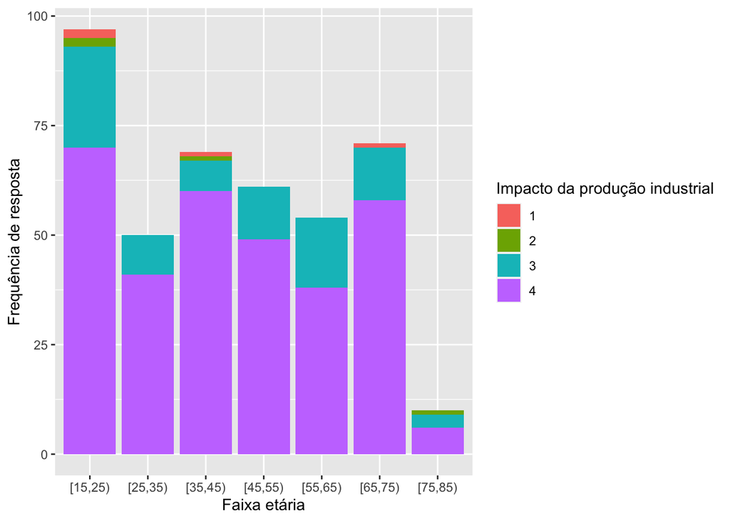

###### Figura 8 - Gráfico de barras empilhadas “Faixa etária” x “Impacto da produção industrial no ambiente”

Embora as preocupações com o impacto da indústria no ambiente sejam muito altas entre todas as faixas etárias, de uma forma generalizada, a imagem acima revela que a faixa etária dos 15-24 anos, comparativamente às restantes, se mostra como a que menos importância atribui ao impacto que a indústria tem no ambiente.

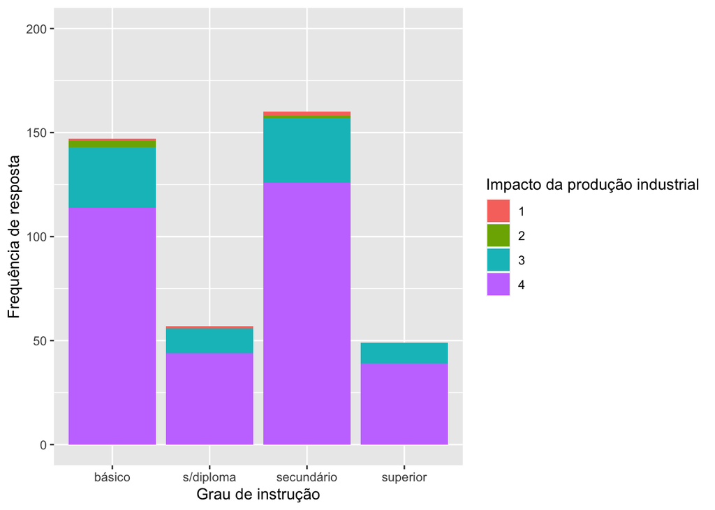

#### Impacto do crescimento económico no ambiente

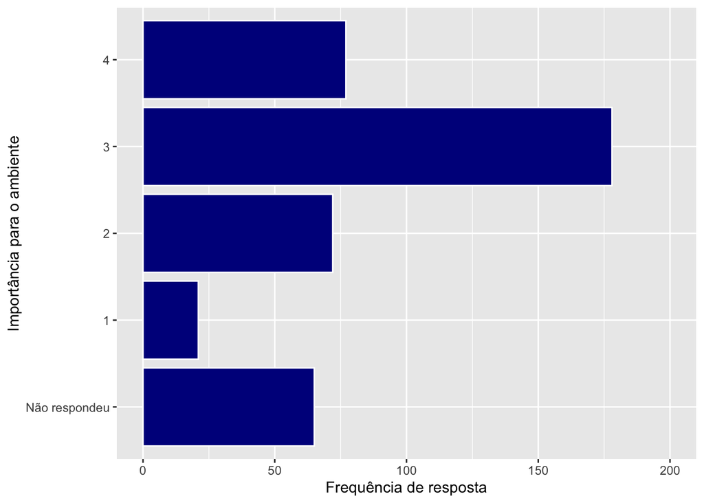

###### Figura 10 - Gráfico de barras horizontais do impacto do crescimento económico no ambiente

Em termos gerais, a classificação mais atribuída ao impacto que o crescimento económico tem no ambiente foi 3, numa escala em que 1 representa nada importante e 4 muito importante.

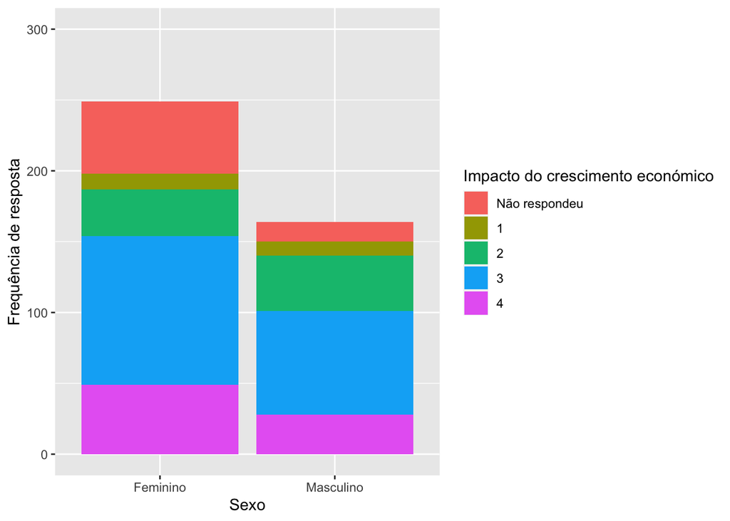

###### Figura 11 - Gráfico de barras empilhadas “Sexo” x “Impacto do crescimento económico no ambiente”

Focando a análise nas respostas por sexo acerca do impacto do crescimento económico no ambiente, é possível concluir que as mulheres optaram mais vezes por não responder do que os homens, e os homens, de uma forma geral, atribuem menos importância ao impacto do crescimento económico no ambiente do que as mulheres.

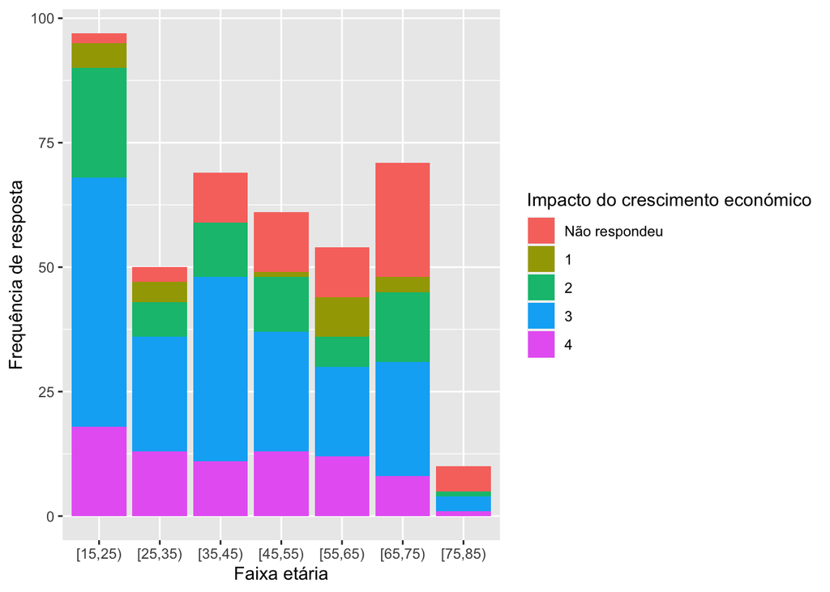

###### Figura 12 - Gráfico de barras empilhadas “Faixa etária” x “Impacto do crescimento económico no ambiente”

Ao nível das faixas etárias, as pessoas com idades compreendidas entre os 65 e os 74 anos foram as que mais optaram por não responder à questão do impacto do crescimento económico no ambiente e, de uma forma generalizada, são os jovens com idades compreendidas entre os 15 e os 24 anos que menos importância dão ao impacto que o crescimento económico tem no ambiente.

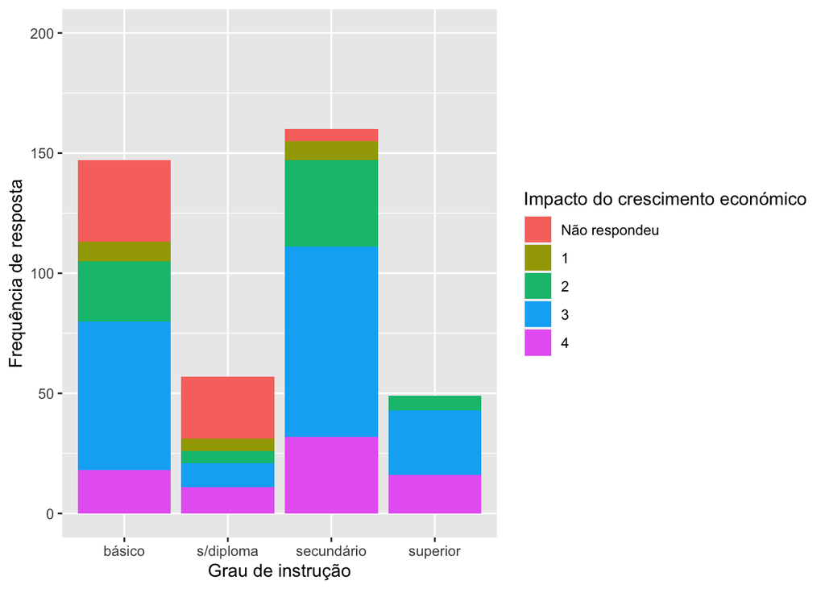

###### Figura 13 - Gráfico de barras empilhadas “Grau de instrução” x “Impacto do crescimento económico no ambiente”

A partir da imagem acima conclui-se que os inquiridos que menos optaram por responder à questão acerca do impacto do crescimento económico no ambiente têm o ensino básico ou não têm diploma. Por outro lado, as classificações mais altas foram atribuídas por inquiridos com o ensino superior.

#### Impacto do aumento do consumo no ambiente

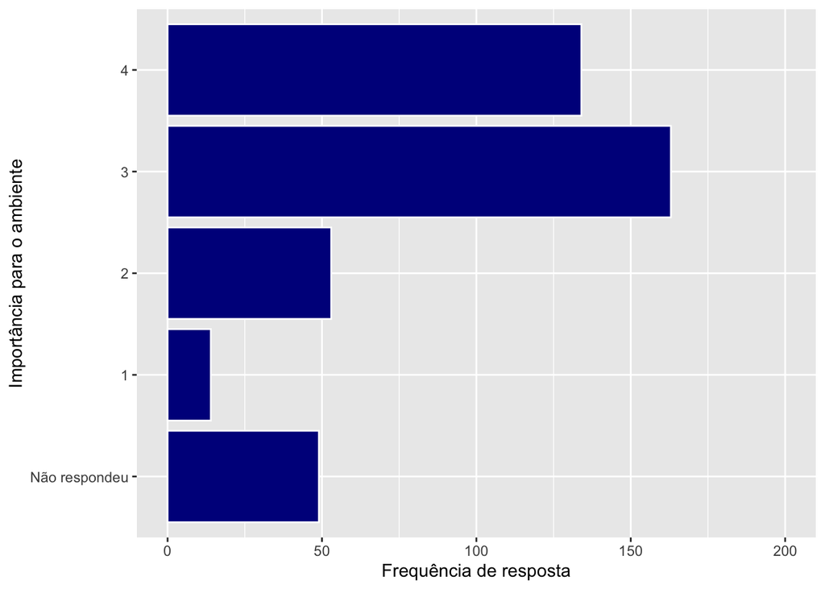

###### Figura 14 - Gráfico de barras horizontais do impacto do aumento do consumo no ambiente

A classificação mais atribuída ao impacto que o aumento dos consumos tem no ambiente ronda os 3 e 4 valores, numa escala em que 1 representa nada importante e 4 muito importante.

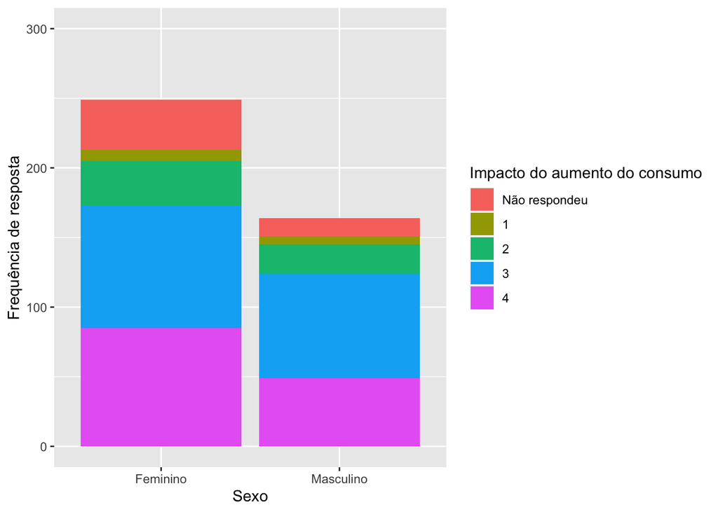

###### Figura 15 - Gráfico de barras empilhadas “Sexo” x “Impacto do aumento do consumo no ambiente”

As respostas por sexo mostram que as mulheres atribuem classificações mais elevadas ao nível da importância que dão ao impacto do aumento dos consumos no ambiente.

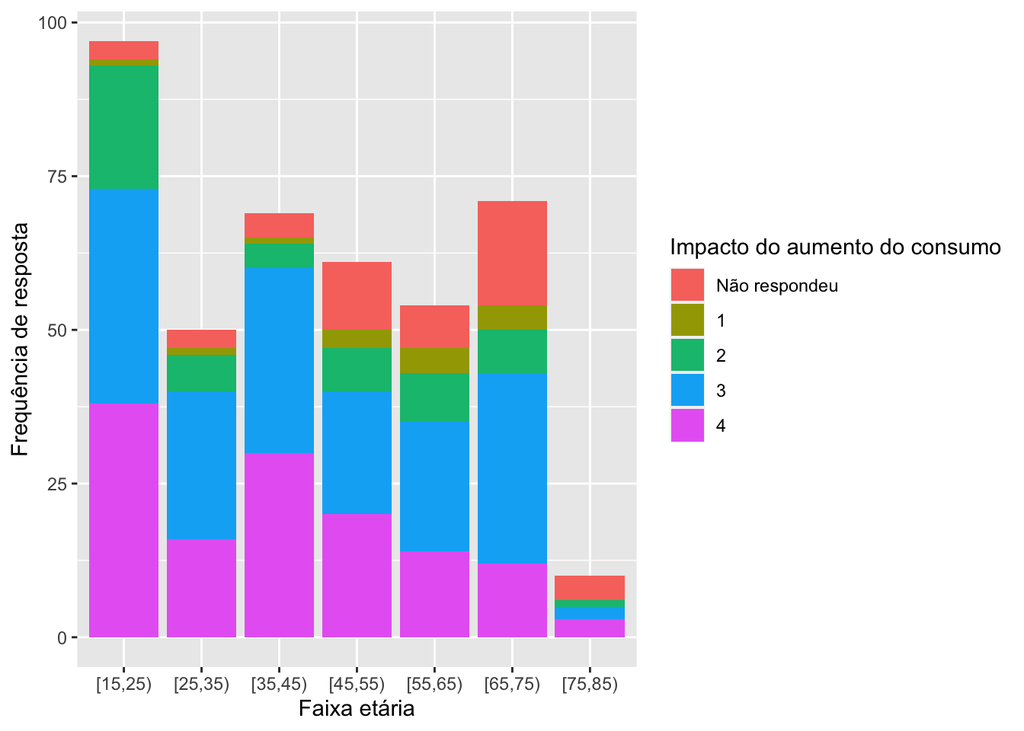

###### Figura 16 - Gráfico de barras empilhadas “Faixa etária” x “Impacto do aumento do consumo no ambiente”

Tal como verificado na questão anterior, as pessoas com idades compreendidas entre os 65 e os 74 anos foram as que mais optaram por não responder à questão do impacto do aumento do consumo no ambiente e, em termos genéricos, as pessoas com idades compreendidas entre os 15 e os 24 anos e entre os 35 e os 44 anos são as que mais importância dão ao impacto que o aumento dos consumo revela ter no ambiente.

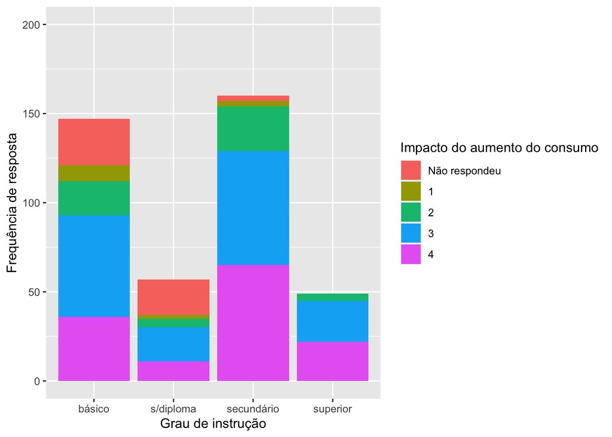

#### Impacto da industrialização da agricultura no ambiente

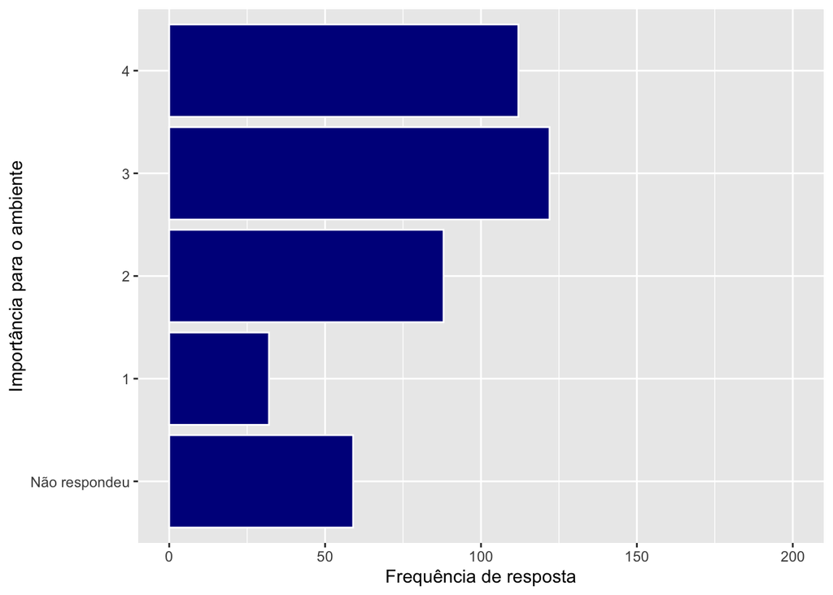

###### Figura 18 - Gráfico de barras horizontais do impacto da industrialização da agricultura no ambiente

As classificações de importância acerca do impacto da industrialização da agricultura no ambiente apresentam-se muito dividas entre os valores 2, 3 e 4, numa escala em que 1 representa nada importante e 4 representa muito importante. De qualquer forma, a classificação 3 volta a ser mais mencionada entre todos os inquiridos.

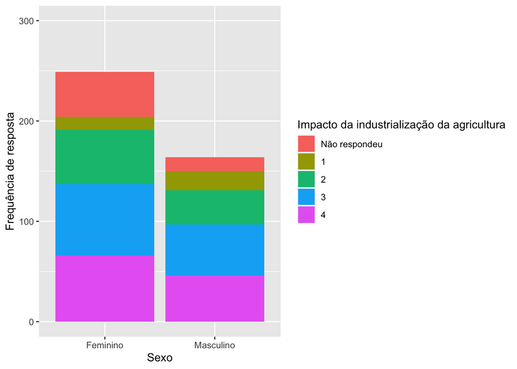

###### Figura 19 - Gráfico de barras empilhadas “Sexo” x “Impacto da industrialização da agricultura no ambiente”

As respostas sobre o impacto da industrialização da agricultura no ambiente apresentam uma consistência muito grande ao nível do sexo. A destacar apenas que as mulheres optaram mais vezes por não responder do que os homens.

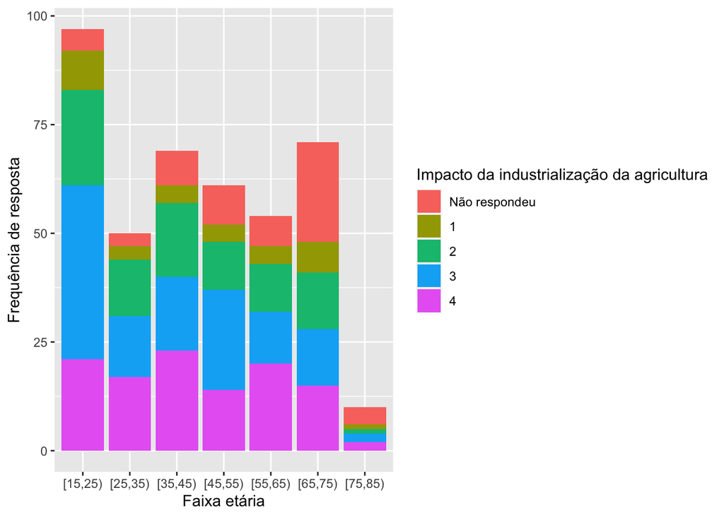

###### Figura 20 - Gráfico de barras empilhadas “Faixa etária” x “Impacto da industrialização da agricultura no ambiente”

No que diz respeito às faixas etárias, as respostas sobre o impacto da industrialização da agricultura no ambiente são consistentes entre todos grupos. Contudo, importa destacar o elevado número de atribuições da classificação 3 por pessoas com idades compreendidas entre os 15 e os 24 anos. À semelhança das categorias de resposta anteriores, a faixa etária dos 65 aos 74 continua a ser a que optou mais vezes por não responder.

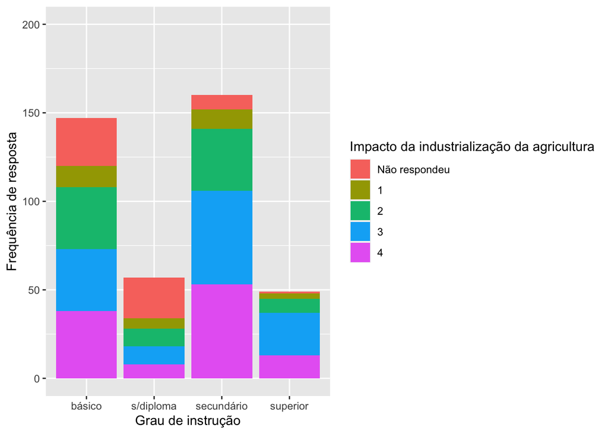

###### Figura 21 - Gráfico de barras empilhadas “Grau de instrução” x “Impacto da industrialização da agricultura no ambiente”

As classificações de importância mais altas foram atribuídas por inquiridos que têm o ensino básico ou o ensino secundário.

#### Impacto da concentração urbana no ambiente

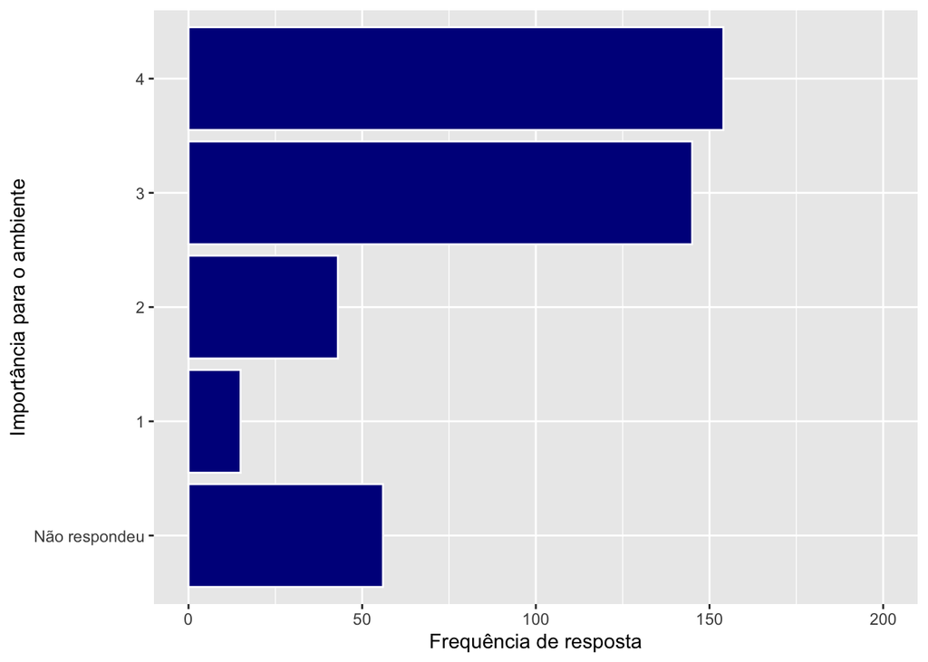

###### Figura 22 - Gráfico de barras horizontais do impacto da concentração urbana no ambiente

A par com o impacto da produção industrial, a concentração urbana também se mostra como um dos temas que gera maior preocupação entre os habitantes da grande Lisboa para o ambiente.

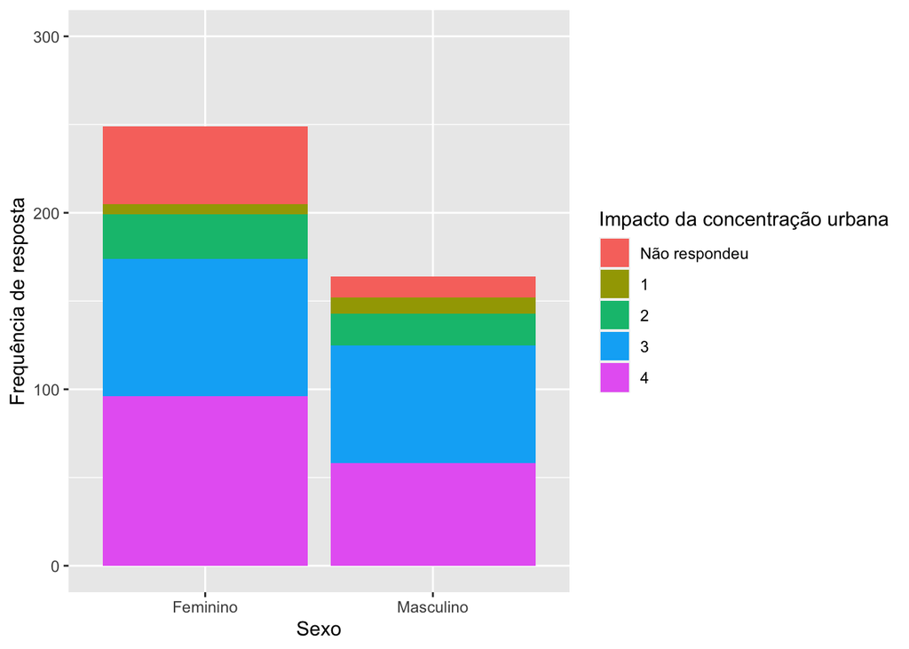

###### Figura 23 - Gráfico de barras empilhadas “Sexo” x “Impacto da concentração urbana no ambiente”

As respostas sobre o impacto da concentração urbana no ambiente também apresentam uma elevada consistência entre os sexos masculino e feminino.

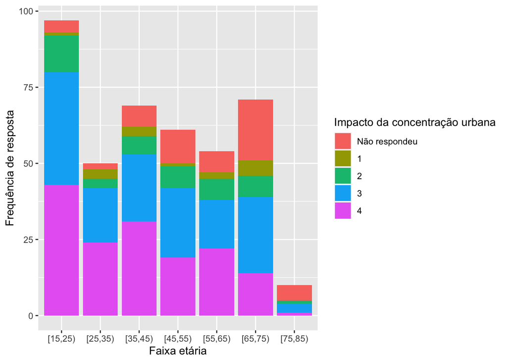

###### Figura 24 - Gráfico de barras empilhadas “Faixa etária” x “Impacto da concentração urbana no ambiente”

No que diz respeito às faixas etárias, o impacto da concentração urbana no ambiente é visto com um maior grau de importância entre jovens com idades compreendidas entre os 15 e os 24 anos.

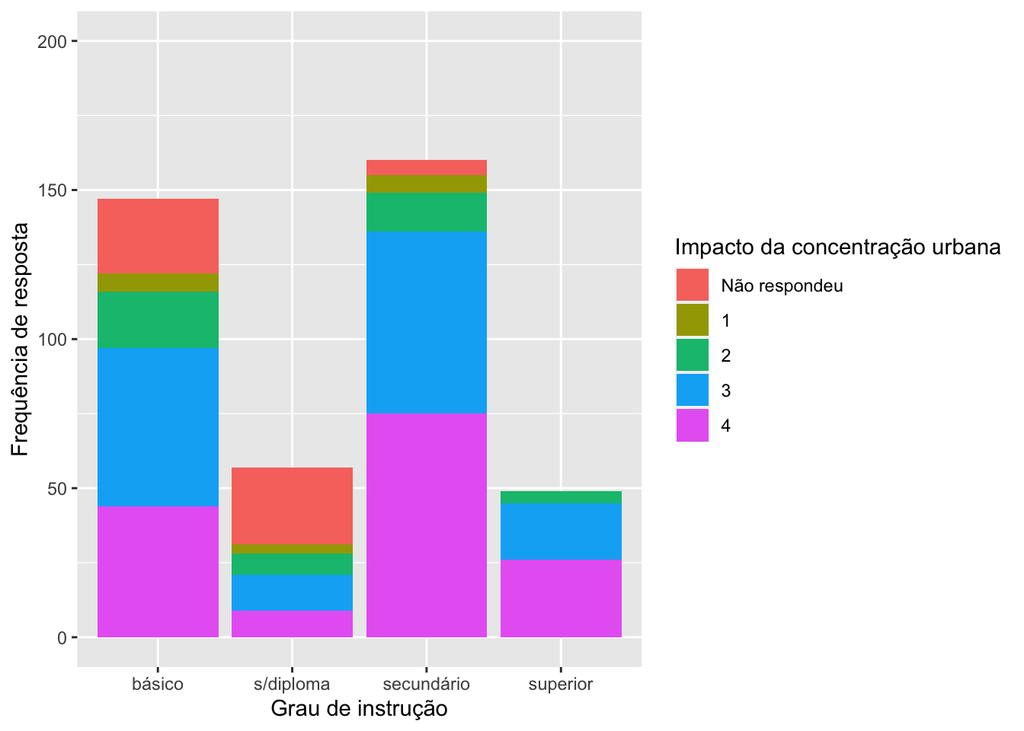

###### Figura 25 - Gráfico de barras empilhadas “Grau de instrução” x “Impacto da concentração urbana no ambiente”

As classificações de importância mais altas foram atribuídas por inquiridos que têm o ensino secundário.

#### Dependência das resoluções ambientais

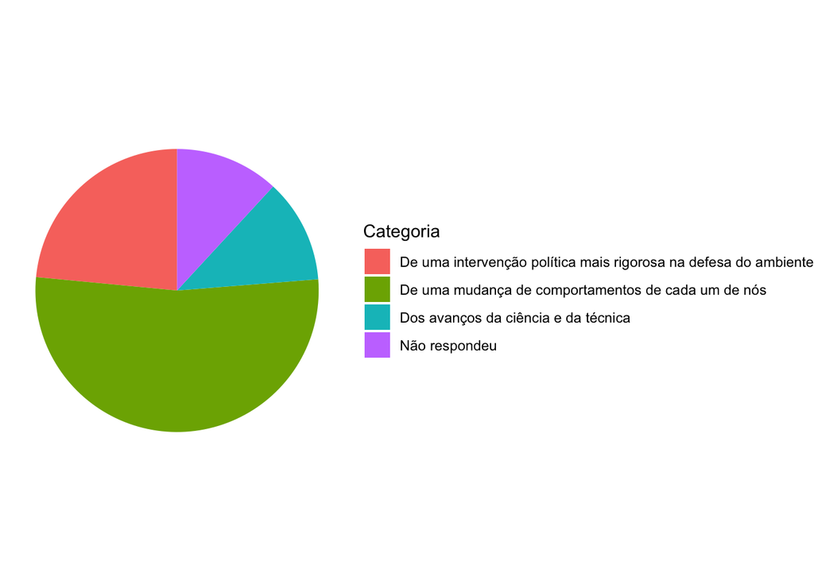

###### Figura 26 - Gráfico circular da dependência das resoluções ambientais

Conforme mostra a imagem acima, mais de 50% dos inquiridos indicam que as resoluções ambientais dependem de uma mudança comportamental dos indíviduos.

#### Temas mais procurados em jornais e revistas

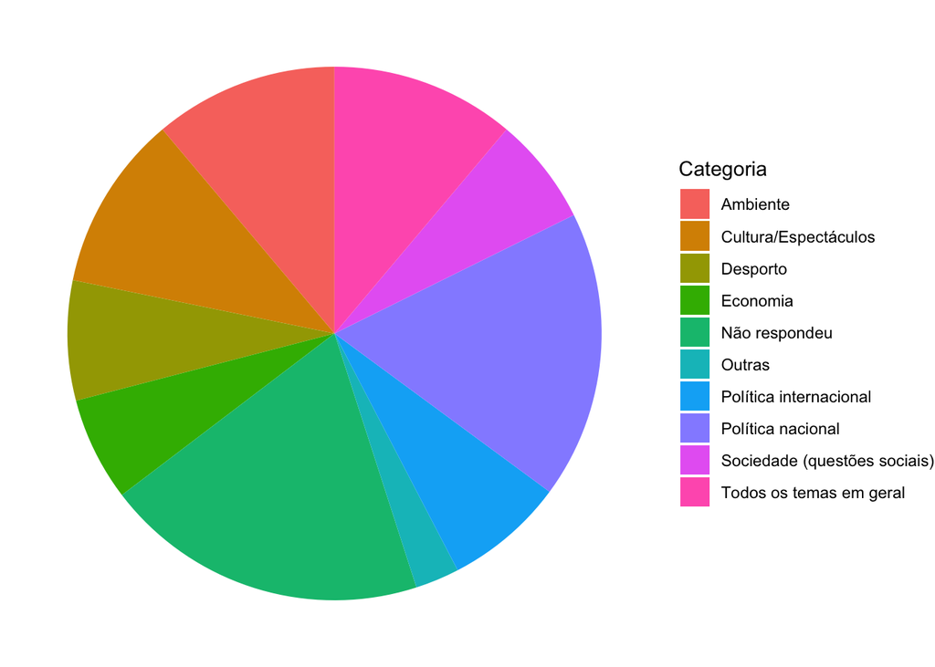

###### Figura 27 - Gráfico circular dos temas mais procurados em jornais e revistas

No que diz respeito aos temas mais procurados em jornais e revistas, o ambiente continua a ver o volume da sua quota de conteúdo muito semelhante e repartido com temas como a cultura e temas genéricos, e vê-se ultrapassado pela política nacional.

#### Medidas do governo

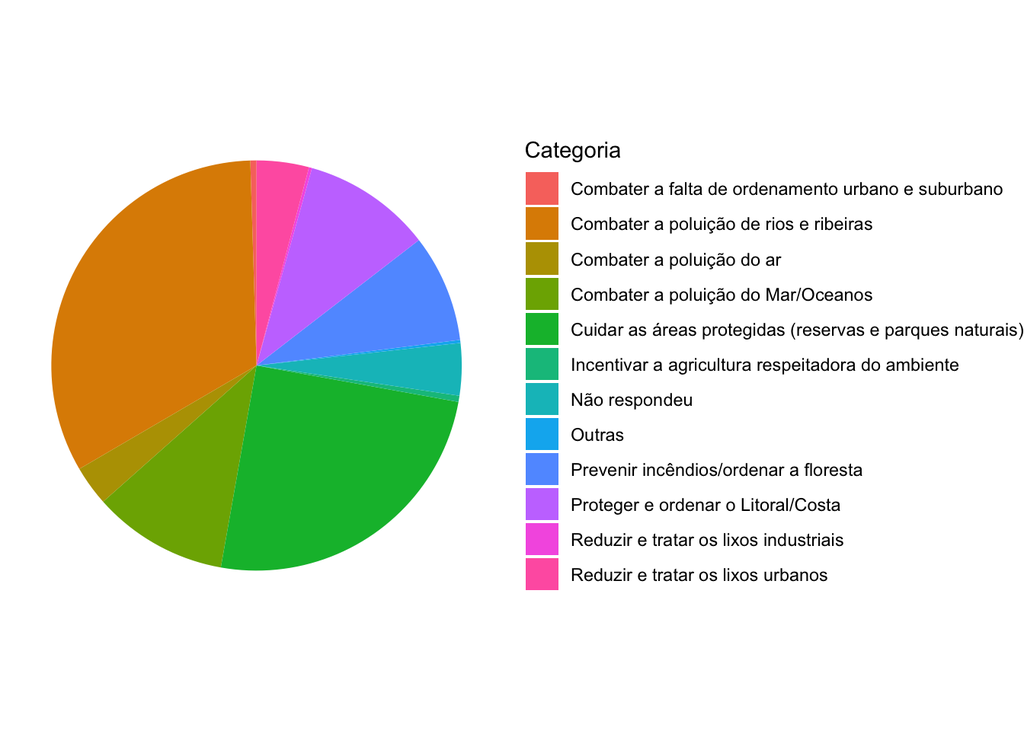

###### Figura 28 - Gráfico circular das medidas do governo

No que diz respeito às principais medidas que devem ser tomadas pelo governo, os inquiridos deram particular atenção ao combate da poluição de rios e ribeiras e a cuidar de áreas protegias, nomeadamente reservas e parques naturais.

Trabalho realizado por:  
- António Teotónio  
- João Dias  
- Diogo Aqueu  
- David Franco

### Webgrafia

[1] https://expresso.pt/sociedade/2021-12-16-Censos-2021-25-das-casas-tem-uma-so-pessoa-la-dentro--e-e-na-regiao-de-Lisboa-que-mais-se-vive-sozinho--5572553b - Consultado a 25/03/2023